# SeqMonk Vistory Report

## Project Summary

### Basic Project Info

| Parameter | Value |
| --- | --- |
| Project Name | pluripotency_exit_input_comparison.smk |
| Vistory Name | pluripotency_exit_input_comparison.smv |
| Genome | Mus musculus GRCm38_v95 |
| SeqMonk Version | 1.46.0 |

### Data Sets

| Name | File Name | Reads | Import Options |
| --- | --- | --- | --- |
| DNMT_TKOInput_1_10KO2i1 | /bi/seqfac/seqfac/200225_Aled_ChIP_Globus/Aligned/Project_Sanger/Sample_lane1/lane1_DNMT_TKOInput_1_10KO2i1_TAGTCTTG_L001_3536STDY8736207_GRCm38_bowtie2.bam | 28931827 | Library type Paired End Dedup=No MAPQ>=20 Primary alignments only. |
| DNMT_TKOInput_1_10KO2i2 | /bi/seqfac/seqfac/200225_Aled_ChIP_Globus/Aligned/Project_Sanger/Sample_lane1/lane1_DNMT_TKOInput_1_10KO2i2_TTCCATTG_L001_3536STDY8736208_GRCm38_bowtie2.bam | 21271478 | Library type Paired End Dedup=No MAPQ>=20 Primary alignments only. |
| DNMT_TKOInput_1_10KO2i3 | /bi/seqfac/seqfac/200225_Aled_ChIP_Globus/Aligned/Project_Sanger/Sample_lane1/lane1_DNMT_TKOInput_1_10KO2i3_TCGAAGTG_L001_3536STDY8736209_GRCm38_bowtie2.bam | 12312860 | Library type Paired End Dedup=No MAPQ>=20 Primary alignments only. |
| DNMT_TKOInput_1_10KOEpiLC1 | /bi/seqfac/seqfac/200225_Aled_ChIP_Globus/Aligned/Project_Sanger/Sample_lane1/lane1_DNMT_TKOInput_1_10KOEpiLC1_TAACGCTG_L001_3536STDY8736210_GRCm38_bowtie2.bam | 19880874 | Library type Paired End Dedup=No MAPQ>=20 Primary alignments only. |
| DNMT_TKOInput_1_10KOEpiLC2 | /bi/seqfac/seqfac/200225_Aled_ChIP_Globus/Aligned/Project_Sanger/Sample_lane1/lane1_DNMT_TKOInput_1_10KOEpiLC2_TTGGTATG_L001_3536STDY8736211_GRCm38_bowtie2.bam | 20670158 | Library type Paired End Dedup=No MAPQ>=20 Primary alignments only. |
| DNMT_TKOInput_1_10KOEpiLC3 | /bi/seqfac/seqfac/200225_Aled_ChIP_Globus/Aligned/Project_Sanger/Sample_lane1/lane1_DNMT_TKOInput_1_10KOEpiLC3_TGAACTGG_L001_3536STDY8736212_GRCm38_bowtie2.bam | 25195174 | Library type Paired End Dedup=No MAPQ>=20 Primary alignments only. |
| DNMT_TKOInput_1_10WT2i1 | /bi/seqfac/seqfac/200225_Aled_ChIP_Globus/Aligned/Project_Sanger/Sample_lane1/lane1_DNMT_TKOInput_1_10WT2i1_TGCGATCT_L001_3536STDY8736201_GRCm38_bowtie2.bam | 28657679 | Library type Paired End Dedup=No MAPQ>=20 Primary alignments only. |
| DNMT_TKOInput_1_10WT2i2 | /bi/seqfac/seqfac/200225_Aled_ChIP_Globus/Aligned/Project_Sanger/Sample_lane1/lane1_DNMT_TKOInput_1_10WT2i2_TTCCTGCT_L001_3536STDY8736202_GRCm38_bowtie2.bam | 23097758 | Library type Paired End Dedup=No MAPQ>=20 Primary alignments only. |
| DNMT_TKOInput_1_10WT2i3 | /bi/seqfac/seqfac/200225_Aled_ChIP_Globus/Aligned/Project_Sanger/Sample_lane1/lane1_DNMT_TKOInput_1_10WT2i3_TAGTGACT_L001_3536STDY8736203_GRCm38_bowtie2.bam | 20889522 | Library type Paired End Dedup=No MAPQ>=20 Primary alignments only. |
| DNMT_TKOInput_1_10WTEpiLC1 | /bi/seqfac/seqfac/200225_Aled_ChIP_Globus/Aligned/Project_Sanger/Sample_lane1/lane1_DNMT_TKOInput_1_10WTEpiLC1_TACAGGAT_L001_3536STDY8736204_GRCm38_bowtie2.bam | 28320642 | Library type Paired End Dedup=No MAPQ>=20 Primary alignments only. |
| DNMT_TKOInput_1_10WTEpiLC2 | /bi/seqfac/seqfac/200225_Aled_ChIP_Globus/Aligned/Project_Sanger/Sample_lane1/lane1_DNMT_TKOInput_1_10WTEpiLC2_TCCTCAAT_L001_3536STDY8736205_GRCm38_bowtie2.bam | 22496023 | Library type Paired End Dedup=No MAPQ>=20 Primary alignments only. |
| DNMT_TKOInput_1_10WTEpiLC3 | /bi/seqfac/seqfac/200225_Aled_ChIP_Globus/Aligned/Project_Sanger/Sample_lane1/lane1_DNMT_TKOInput_1_10WTEpiLC3_TGTGGTTG_L001_3536STDY8736206_GRCm38_bowtie2.bam | 20464019 | Library type Paired End Dedup=No MAPQ>=20 Primary alignments only. |
| TET_KO_2i_Input_(from_K27Ac)_rep1_valid_regions | Reimported from TET_KO_2i_Input_(from_K27Ac)_rep1_sensible_regions | 21475967 | Visible stores parser Filter by feature Excluding excluded regions 2kb Remove DuplicatesNo |
| TET_KO_2i_Input_(from_K27Ac)_rep2_valid_regions | Reimported from TET_KO_2i_Input_(from_K27Ac)_rep2_sensible_regions | 25888215 | Visible stores parser Filter by feature Excluding excluded regions 2kb Remove DuplicatesNo |
| TET_KO_2i_Input_(from_K27Ac)_rep3_valid_regions | Reimported from TET_KO_2i_Input_(from_K27Ac)_rep3_sensible_regions | 23808429 | Visible stores parser Filter by feature Excluding excluded regions 2kb Remove DuplicatesNo |
| TET_KO_EpiLC_Input_(from_K27Ac)_rep1_valid_regions | Reimported from TET_KO_EpiLC_Input_(from_K27Ac)_rep1_sensible_regions | 28776866 | Visible stores parser Filter by feature Excluding excluded regions 2kb Remove DuplicatesNo |
| TET_KO_EpiLC_Input_(from_K27Ac)_rep2_valid_regions | Reimported from TET_KO_EpiLC_Input_(from_K27Ac)_rep2_sensible_regions | 30189166 | Visible stores parser Filter by feature Excluding excluded regions 2kb Remove DuplicatesNo |
| TET_KO_EpiLC_Input_(from_K27Ac)_rep3_valid_regions | Reimported from TET_KO_EpiLC_Input_(from_K27Ac)_rep3_sensible_regions | 27676372 | Visible stores parser Filter by feature Excluding excluded regions 2kb Remove DuplicatesNo |
| TET_WT_2i_Input_(from_K27Ac)_rep1_valid_regions | Reimported from TET_WT_2i_Input_(from_K27Ac)_rep1_sensible_regions | 35912967 | Visible stores parser Filter by feature Excluding excluded regions 2kb Remove DuplicatesNo |
| TET_WT_2i_Input_(from_K27Ac)_rep2_valid_regions | Reimported from TET_WT_2i_Input_(from_K27Ac)_rep2_sensible_regions | 32417426 | Visible stores parser Filter by feature Excluding excluded regions 2kb Remove DuplicatesNo |
| TET_WT_2i_Input_(from_K27Ac)_rep3_valid_regions | Reimported from TET_WT_2i_Input_(from_K27Ac)_rep3_sensible_regions | 33773024 | Visible stores parser Filter by feature Excluding excluded regions 2kb Remove DuplicatesNo |
| TET_WT_EpiLC_Input_(from_K27Ac)_rep1_valid_regions | Reimported from TET_WT_EpiLC_Input_(from_K27Ac)_rep1_sensible_regions | 35148305 | Visible stores parser Filter by feature Excluding excluded regions 2kb Remove DuplicatesNo |
| TET_WT_EpiLC_Input_(from_K27Ac)_rep2_valid_regions | Reimported from TET_WT_EpiLC_Input_(from_K27Ac)_rep2_sensible_regions | 29526185 | Visible stores parser Filter by feature Excluding excluded regions 2kb Remove DuplicatesNo |
| TET_WT_EpiLC_Input_(from_K27Ac)_rep3_valid_regions | Reimported from TET_WT_EpiLC_Input_(from_K27Ac)_rep3_sensible_regions | 28687101 | Visible stores parser Filter by feature Excluding excluded regions 2kb Remove DuplicatesNo |

### Replicate Sets

| DNMT_TKOInput_1_10KO2i | DNMT_TKOInput_1_10KOEpiLC | DNMT_TKOInput_1_10WT2i | DNMT_TKOInput_1_10WTEpiLC | TET_KO_2i_Input | TET_KO_EpiLC_Input | TET_WT_2i_Input | TET_WT_EpiLC_Input |
| --- | --- | --- | --- | --- | --- | --- | --- |
| DNMT_TKOInput_1_10KO2i1 | DNMT_TKOInput_1_10KOEpiLC1 | DNMT_TKOInput_1_10WT2i1 | DNMT_TKOInput_1_10WTEpiLC1 | TET_KO_2i_Input_(from_K27Ac)_rep1_valid_regions | TET_KO_EpiLC_Input_(from_K27Ac)_rep1_valid_regions | TET_WT_2i_Input_(from_K27Ac)_rep1_valid_regions | TET_WT_EpiLC_Input_(from_K27Ac)_rep1_valid_regions |
| DNMT_TKOInput_1_10KO2i2 | DNMT_TKOInput_1_10KOEpiLC2 | DNMT_TKOInput_1_10WT2i2 | DNMT_TKOInput_1_10WTEpiLC2 | TET_KO_2i_Input_(from_K27Ac)_rep2_valid_regions | TET_KO_EpiLC_Input_(from_K27Ac)_rep2_valid_regions | TET_WT_2i_Input_(from_K27Ac)_rep2_valid_regions | TET_WT_EpiLC_Input_(from_K27Ac)_rep2_valid_regions |
| DNMT_TKOInput_1_10KO2i3 | DNMT_TKOInput_1_10KOEpiLC3 | DNMT_TKOInput_1_10WT2i3 | DNMT_TKOInput_1_10WTEpiLC3 | TET_KO_2i_Input_(from_K27Ac)_rep3_valid_regions | TET_KO_EpiLC_Input_(from_K27Ac)_rep3_valid_regions | TET_WT_2i_Input_(from_K27Ac)_rep3_valid_regions | TET_WT_EpiLC_Input_(from_K27Ac)_rep3_valid_regions |

### Quantitation

| Name | Parent | Probes | Description | Comments |
| --- | --- | --- | --- | --- |
| 2 kb tiles |  | 1362779 | Running windows of size 2000 with step size 2000. Quantitated with Read Count Quantitation using All Reads correcting for total count per million reads log transformed |  |

This is to look at a) coverage outliers and b) at regions which are genetically different between the strains and therefore should be taken out of the analysis. We already know that for some reason the TET WT and the TET TKO don't have the same genetic background. After much deliberation I came up with a set of excluded regions for this comparsion. I'll see what those regions look like and if they include the coverage outliers for the DNMT samples.

Importing file excluded_regions_191112.txt as annotation 'excluded regions TKO'.

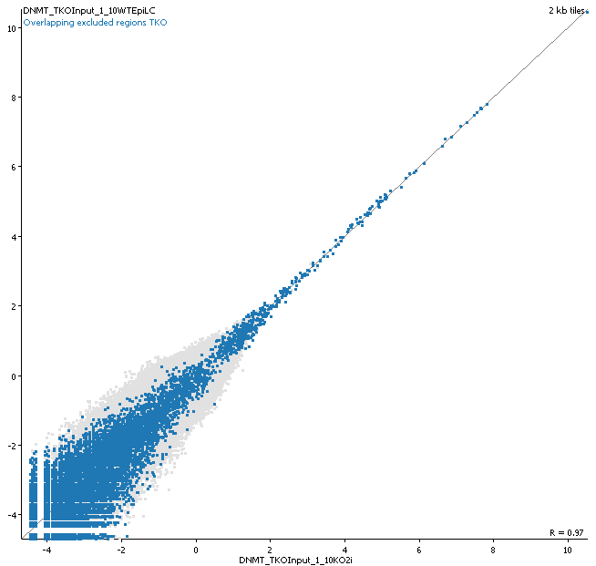

These include coverage outliers. Also DNMT TKO and WT generally have very similar coverage (as have EpiLC and 2i) which is good!

New Probe List

Not Overlapping excluded regions TKO (1231453 probes):[Feature Filter] Filter probes in 2 kb tiles on regions based on excluded regions TKO Over feature relationship is Not Overlapping

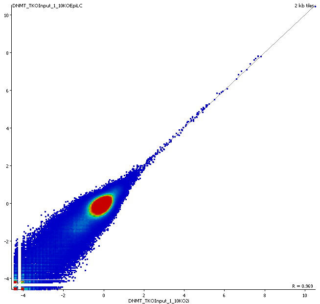

Unfortunately, not all coverage outliers were excluded, so need an additional filter. Let's to > 2

New Probe List

Value above 2 in any (146 probes):[Probe Values Filter] Filter on probes in 2 kb tiles where at least 1 of DNMT_TKOInput_1_10KO2i , DNMT_TKOInput_1_10KOEpiLC , DNMT_TKOInput_1_10WT2i , DNMT_TKOInput_1_10WTEpiLC , TET_KO_2i_Input , TET_KO_EpiLC_Input , TET_WT_2i_Input , TET_WT_EpiLC_Input had a value above 2.0. Quantitation was Read Count Quantitation using All Reads correcting for total count per million reads log transformed

New Probe List

excluded_regions_all_input_200425 (131335 probes):[Combine Filter] Overlapping excluded regions TKO OR Value above 2 in any

New Probe Set

excluded_regions_all_input_200425 (131335 probes):Running windows of size 2000 with step size 2000. Quantitated with Read Count Quantitation using All Reads correcting for total count per million reads log transformed then took subset of probes in excluded_regions_all_input_200425

Probes Quantitated

Fixed Value Quantitation using a value of 1

New Probe Set

excluded_regions_all_input_200425 (15427 probes):Deduplicated probes from excluded_regions_all_input_200425 created by Running windows of size 2000 with step size 2000. Quantitated with Read Count Quantitation using All Reads correcting for total count per million reads log transformed then took subset of probes in excluded_regions_all_input_200425. Quantitated with Fixed Value Quantitation using a value of 1Max Distance was 1 strands were merged separately

Probes Quantitated

Fixed Value Quantitation using a value of 1

This exercise was to merge adjacent exlcuded regions, then converted to an annotation track called excluded_regions_all_input_200425 and exported as probe report

New Probe Set:2 kb tiles (1362779 probes)

Running windows of size 2000 with step size 2000

Probes Quantitated

Read Count Quantitation using All Reads correcting for total count per million reads log transformed

New Probe List: Not Overlapping excluded_regions_all_input_200425 (1231444 probes)

[Feature Filter] Filter probes in 2 kb tiles on regions based on excluded_regions_all_input_200425 Over feature relationship is Not Overlapping

Actually, I should also exclude the regions that are very different between DNMT and TET cell lines

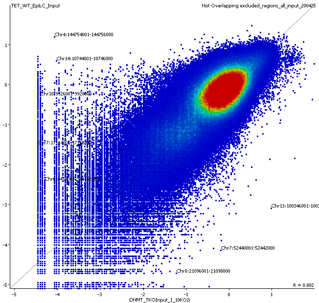

How about I go for differences of > 2

New Probe List: Difference above 2 (1751 probes)

[Differences Filter] Filter on probes in Not Overlapping excluded_regions_all_input_200425 where average difference when comparing DNMT_TKOInput_1_10KO2i to TET_WT_EpiLC_Input had a value above 2.0. Quantitation was Read Count Quantitation using All Reads correcting for total count per million reads log transformed

New Probe List: Difference below -2 (639 probes)

[Differences Filter] Filter on probes in Not Overlapping excluded_regions_all_input_200425 where average difference when comparing DNMT_TKOInput_1_10KO2i to TET_WT_EpiLC_Input had a value below -2.0. Quantitation was Read Count Quantitation using All Reads correcting for total count per million reads log transformed

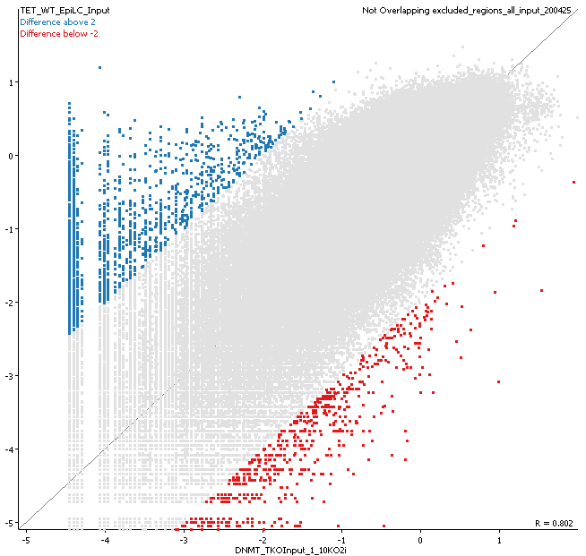

adding those to the annotation and then merging

New Probe Set:All Probes (143901 probes)

Feature generator using excluded_regions_all_input_200425 duplicates removed Over feature from 0-0

Probes Quantitated

Fixed Value Quantitation using a value of 1

New Probe Set:excluded_regions_all_input_200425 (16460 probes)

Deduplicated probes from All Probes created by Feature generator using excluded_regions_all_input_200425 duplicates removed Over feature from 0-0. Quantitated with Fixed Value Quantitation using a value of 1Max Distance was 1 strands were merged separately

Probes Quantitated

Fixed Value Quantitation using a value of 1

saved as new annotation track and exported a probe report